# **Problem Statement**

## Business Context

A sales forecast is a prediction of future sales revenue based on historical data, industry trends, and the status of the current sales pipeline. Businesses use the sales forecast to estimate weekly, monthly, quarterly, and annual sales totals. A company needs to make an accurate sales forecast as it adds value across an organization and helps the different verticals to chalk out their future course of action.

Forecasting helps an organization plan its sales operations by region and provides valuable insights to the supply chain team regarding the procurement of goods and materials. An accurate sales forecast process has many benefits which include improved decision-making about the future and reduction of sales pipeline and forecast risks. Moreover, it helps to reduce the time spent in planning territory coverage and establish benchmarks that can be used to assess trends in the future.

## Objective

SuperKart is a retail chain operating supermarkets and food marts across various tier cities, offering a wide range of products. To optimize its inventory management and make informed decisions around regional sales strategies, SuperKart wants to accurately forecast the sales revenue of its outlets for the upcoming quarter.

To operationalize these insights at scale, the company has partnered with a data science firm—not just to build a predictive model based on historical sales data, but to develop and deploy a robust forecasting solution that can be integrated into SuperKart’s decision-making systems and used across its network of stores.

## Data Description

The data contains the different attributes of the various products and stores.The detailed data dictionary is given below.

- **Product_Id** - unique identifier of each product, each identifier having two letters at the beginning followed by a number.
- **Product_Weight** - weight of each product
- **Product_Sugar_Content** - sugar content of each product like low sugar, regular and no sugar
- **Product_Allocated_Area** - ratio of the allocated display area of each product to the total display area of all the products in a store
- **Product_Type** - broad category for each product like meat, snack foods, hard drinks, dairy, canned, soft drinks, health and hygiene, baking goods, bread, breakfast, frozen foods, fruits and vegetables, household, seafood, starchy foods, others
- **Product_MRP** - maximum retail price of each product
- **Store_Id** - unique identifier of each store
- **Store_Establishment_Year** - year in which the store was established
- **Store_Size** - size of the store depending on sq. feet like high, medium and low
- **Store_Location_City_Type** - type of city in which the store is located like Tier 1, Tier 2 and Tier 3. Tier 1 consists of cities where the standard of living is comparatively higher than its Tier 2 and Tier 3 counterparts.
- **Store_Type** - type of store depending on the products that are being sold there like Departmental Store, Supermarket Type 1, Supermarket Type 2 and Food Mart
- **Product_Store_Sales_Total** - total revenue generated by the sale of that particular product in that particular store

# **Installing and Importing the necessary libraries**

```python
#Installing the libraries with the specified versions
!pip install numpy==2.0.2 pandas==2.2.2 scikit-learn==1.6.1 matplotlib==3.10.0 seaborn==0.13.2 joblib==1.4.2 xgboost==2.1.4 requests==2.32.4 huggingface_hub==0.30.1 -q
```

**Note:**

- After running the above cell, kindly restart the notebook kernel (for Jupyter Notebook) or runtime (for Google Colab) and run all cells sequentially from the next cell.
- On executing the above line of code, you might see a warning regarding package dependencies. This error message can be ignored as the above code ensures that all necessary libraries and their dependencies are maintained to successfully execute the code in this notebook.

```python
import warnings
warnings.filterwarnings("ignore")

# Libraries to help with reading and manipulating data
import numpy as np
import pandas as pd

# For splitting the dataset
from sklearn.model_selection import train_test_split

# Libaries to help with data visualization
import matplotlib.pyplot as plt
import seaborn as sns

# Removes the limit for the number of displayed columns
pd.set_option("display.max_columns", None)
# Sets the limit for the number of displayed rows
pd.set_option("display.max_rows", 100)


# Libraries different ensemble classifiers
from sklearn.ensemble import (
    BaggingRegressor,
    RandomForestRegressor,
    AdaBoostRegressor,
    GradientBoostingRegressor,
)
from xgboost import XGBRegressor
from sklearn.tree import DecisionTreeRegressor

# Libraries to get different metric scores
from sklearn.metrics import (
    confusion_matrix,
    accuracy_score,
    precision_score,
    recall_score,
    f1_score,
    mean_squared_error,
    mean_absolute_error,
    r2_score,
    mean_absolute_percentage_error
)

# To create the pipeline
from sklearn.compose import make_column_transformer
from sklearn.pipeline import make_pipeline,Pipeline

# To tune different models and standardize
from sklearn.model_selection import GridSearchCV
from sklearn.preprocessing import StandardScaler,OneHotEncoder

# To serialize the model
import joblib

# os related functionalities
import os

# API request
import requests

# for hugging face space authentication to upload files
from huggingface_hub import login, HfApi
```

# **Loading the dataset**

```python
from google.colab import drive
drive.mount('/content/drive')
```

```python
##  Code to read the data from the drive
kart = pd.read_csv("/content/drive/MyDrive/Notebooks/Model_Deployment/Assignment/SuperKart.csv")
```

```python
# copying data to another variable to avoid any changes to original data
data = kart.copy()
```

# **Data Overview**

```python
## Code to view top 5 rows of the training data
data.head(5)
```

|  | Product_Id | Product_Weight | Product_Sugar_Content | Product_Allocated_Area | Product_Type | Product_MRP | Store_Id | Store_Establishment_Year | Store_Size | Store_Location_City_Type | Store_Type | Product_Store_Sales_Total |
| --- | --- | --- | --- | --- | --- | --- | --- | --- | --- | --- | --- | --- |
| 0 | FD6114 | 12.66 | Low Sugar | 0.027 | Frozen Foods | 117.08 | OUT004 | 2009 | Medium | Tier 2 | Supermarket Type2 | 2842.40 |
| 1 | FD7839 | 16.54 | Low Sugar | 0.144 | Dairy | 171.43 | OUT003 | 1999 | Medium | Tier 1 | Departmental Store | 4830.02 |
| 2 | FD5075 | 14.28 | Regular | 0.031 | Canned | 162.08 | OUT001 | 1987 | High | Tier 2 | Supermarket Type1 | 4130.16 |
| 3 | FD8233 | 12.10 | Low Sugar | 0.112 | Baking Goods | 186.31 | OUT001 | 1987 | High | Tier 2 | Supermarket Type1 | 4132.18 |
| 4 | NC1180 | 9.57 | No Sugar | 0.010 | Health and Hygiene | 123.67 | OUT002 | 1998 | Small | Tier 3 | Food Mart | 2279.36 |

```python
## Code to view last 5 rows of the training data
data.tail(5)
```

|  | Product_Id | Product_Weight | Product_Sugar_Content | Product_Allocated_Area | Product_Type | Product_MRP | Store_Id | Store_Establishment_Year | Store_Size | Store_Location_City_Type | Store_Type | Product_Store_Sales_Total |
| --- | --- | --- | --- | --- | --- | --- | --- | --- | --- | --- | --- | --- |
| 8758 | NC7546 | 14.80 | No Sugar | 0.016 | Health and Hygiene | 140.53 | OUT004 | 2009 | Medium | Tier 2 | Supermarket Type2 | 3806.53 |
| 8759 | NC584 | 14.06 | No Sugar | 0.142 | Household | 144.51 | OUT004 | 2009 | Medium | Tier 2 | Supermarket Type2 | 5020.74 |
| 8760 | NC2471 | 13.48 | No Sugar | 0.017 | Health and Hygiene | 88.58 | OUT001 | 1987 | High | Tier 2 | Supermarket Type1 | 2443.42 |
| 8761 | NC7187 | 13.89 | No Sugar | 0.193 | Household | 168.44 | OUT001 | 1987 | High | Tier 2 | Supermarket Type1 | 4171.82 |
| 8762 | FD306 | 14.73 | Low Sugar | 0.177 | Snack Foods | 224.93 | OUT002 | 1998 | Small | Tier 3 | Food Mart | 2186.08 |

```python
# Code to view 10 random sample rows of the test data
data.sample(10)
```

|  | Product_Id | Product_Weight | Product_Sugar_Content | Product_Allocated_Area | Product_Type | Product_MRP | Store_Id | Store_Establishment_Year | Store_Size | Store_Location_City_Type | Store_Type | Product_Store_Sales_Total |
| --- | --- | --- | --- | --- | --- | --- | --- | --- | --- | --- | --- | --- |
| 414 | DR835 | 14.62 | Regular | 0.119 | Hard Drinks | 199.73 | OUT001 | 1987 | High | Tier 2 | Supermarket Type1 | 4976.47 |
| 6535 | DR3678 | 12.03 | Low Sugar | 0.029 | Soft Drinks | 148.61 | OUT004 | 2009 | Medium | Tier 2 | Supermarket Type2 | 3345.85 |
| 2950 | NC8159 | 12.73 | No Sugar | 0.137 | Household | 146.30 | OUT004 | 2009 | Medium | Tier 2 | Supermarket Type2 | 3454.89 |
| 2466 | FD463 | 12.03 | Low Sugar | 0.048 | Dairy | 176.72 | OUT004 | 2009 | Medium | Tier 2 | Supermarket Type2 | 2255.43 |
| 7866 | FD5316 | 10.18 | Low Sugar | 0.021 | Frozen Foods | 112.92 | OUT002 | 1998 | Small | Tier 3 | Food Mart | 2197.53 |
| 3426 | FD5690 | 11.49 | Low Sugar | 0.023 | Frozen Foods | 148.49 | OUT004 | 2009 | Medium | Tier 2 | Supermarket Type2 | 3219.96 |
| 1317 | FD2676 | 8.87 | Low Sugar | 0.088 | Baking Goods | 113.03 | OUT002 | 1998 | Small | Tier 3 | Food Mart | 1901.95 |
| 8261 | FD6434 | 12.21 | Regular | 0.070 | Fruits and Vegetables | 135.67 | OUT004 | 2009 | Medium | Tier 2 | Supermarket Type2 | 3121.07 |
| 7054 | FD3798 | 16.28 | Low Sugar | 0.047 | Dairy | 136.19 | OUT001 | 1987 | High | Tier 2 | Supermarket Type1 | 4050.33 |
| 3294 | FD2980 | 11.15 | Low Sugar | 0.165 | Baking Goods | 131.87 | OUT004 | 2009 | Medium | Tier 2 | Supermarket Type2 | 2803.37 |

```python
# counting row and column
print('The data frame has',data.shape[0],'rows and',data.shape[1],'columns')
```

```
The data frame has 8763 rows and 12 columns
```

```python
# checking data types
data.info()
```

```
<class 'pandas.core.frame.DataFrame'>
RangeIndex: 8763 entries, 0 to 8762
Data columns (total 12 columns):
 #   Column                     Non-Null Count  Dtype
---  ------                     --------------  -----
 0   Product_Id                 8763 non-null   object
 1   Product_Weight             8763 non-null   float64
 2   Product_Sugar_Content      8763 non-null   object
 3   Product_Allocated_Area     8763 non-null   float64
 4   Product_Type               8763 non-null   object
 5   Product_MRP                8763 non-null   float64
 6   Store_Id                   8763 non-null   object
 7   Store_Establishment_Year   8763 non-null   int64
 8   Store_Size                 8763 non-null   object
 9   Store_Location_City_Type   8763 non-null   object
 10  Store_Type                 8763 non-null   object
 11  Product_Store_Sales_Total  8763 non-null   float64
dtypes: float64(4), int64(1), object(7)
memory usage: 821.7+ KB
```

```python
# checking for duplicate values
data.duplicated().sum()
```

```
np.int64(0)
```

```python
# checking for missing values in the data
data.isnull().sum()
```

|  | 0 |
| --- | --- |
| Product_Id | 0 |
| Product_Weight | 0 |
| Product_Sugar_Content | 0 |
| Product_Allocated_Area | 0 |
| Product_Type | 0 |
| Product_MRP | 0 |
| Store_Id | 0 |
| Store_Establishment_Year | 0 |
| Store_Size | 0 |
| Store_Location_City_Type | 0 |
| Store_Type | 0 |
| Product_Store_Sales_Total | 0 |

**dtype:** int64

```python
# check the statistical summary of the data
data.describe(include="all").T
```

|  | count | unique | top | freq | mean | std | min | 25% | 50% | 75% | max |
| --- | --- | --- | --- | --- | --- | --- | --- | --- | --- | --- | --- |
| Product_Id | 8763 | 8763 | FD306 | 1 | NaN | NaN | NaN | NaN | NaN | NaN | NaN |
| Product_Weight | 8763.0 | NaN | NaN | NaN | 12.653792 | 2.21732 | 4.0 | 11.15 | 12.66 | 14.18 | 22.0 |
| Product_Sugar_Content | 8763 | 4 | Low Sugar | 4885 | NaN | NaN | NaN | NaN | NaN | NaN | NaN |
| Product_Allocated_Area | 8763.0 | NaN | NaN | NaN | 0.068786 | 0.048204 | 0.004 | 0.031 | 0.056 | 0.096 | 0.298 |
| Product_Type | 8763 | 16 | Fruits and Vegetables | 1249 | NaN | NaN | NaN | NaN | NaN | NaN | NaN |
| Product_MRP | 8763.0 | NaN | NaN | NaN | 147.032539 | 30.69411 | 31.0 | 126.16 | 146.74 | 167.585 | 266.0 |
| Store_Id | 8763 | 4 | OUT004 | 4676 | NaN | NaN | NaN | NaN | NaN | NaN | NaN |
| Store_Establishment_Year | 8763.0 | NaN | NaN | NaN | 2002.032751 | 8.388381 | 1987.0 | 1998.0 | 2009.0 | 2009.0 | 2009.0 |
| Store_Size | 8763 | 3 | Medium | 6025 | NaN | NaN | NaN | NaN | NaN | NaN | NaN |
| Store_Location_City_Type | 8763 | 3 | Tier 2 | 6262 | NaN | NaN | NaN | NaN | NaN | NaN | NaN |
| Store_Type | 8763 | 4 | Supermarket Type2 | 4676 | NaN | NaN | NaN | NaN | NaN | NaN | NaN |
| Product_Store_Sales_Total | 8763.0 | NaN | NaN | NaN | 3464.00364 | 1065.630494 | 33.0 | 2761.715 | 3452.34 | 4145.165 | 8000.0 |

```python
# Check unique values in categorical columns
print("Unique values in categorical columns:")
categorical_columns = data.select_dtypes(include=['object']).columns
for col in categorical_columns:
    print(f"\n{col}: {data[col].nunique()} unique values")
    print(data[col].value_counts().head())
```

```
Unique values in categorical columns:

Product_Id: 8763 unique values
Product_Id
FD306     1
FD6114    1
FD7839    1
FD5075    1
FD8233    1
Name: count, dtype: int64

Product_Sugar_Content: 4 unique values
Product_Sugar_Content
Low Sugar    4885
Regular      2251
No Sugar     1519
reg           108
Name: count, dtype: int64

Product_Type: 16 unique values
Product_Type
Fruits and Vegetables    1249
Snack Foods              1149
Frozen Foods              811
Dairy                     796
Household                 740
Name: count, dtype: int64

Store_Id: 4 unique values
Store_Id
OUT004    4676
OUT001    1586
OUT003    1349
OUT002    1152
Name: count, dtype: int64

Store_Size: 3 unique values
Store_Size
Medium    6025
High      1586
Small     1152
Name: count, dtype: int64

Store_Location_City_Type: 3 unique values
Store_Location_City_Type
Tier 2    6262
Tier 1    1349
Tier 3    1152
Name: count, dtype: int64

Store_Type: 4 unique values
Store_Type
Supermarket Type2     4676
Supermarket Type1     1586
Departmental Store    1349
Food Mart             1152
Name: count, dtype: int64
```

#### Observations

- The dataset contains **8,763 rows and 12 columns** with **no missing values**.
- All numeric features are well populated, including *Product_Weight, Product_Allocated_Area, Product_MRP, Store_Establishment_Year,* and *Product_Store_Sales_Total*.

**Feature-level insights:**

- **Product_Weight** is fairly centered around ~12.6, with a moderate spread (min: 4, max: 22).
- **Product_MRP** ranges from 31 to 266, indicating healthy price variability across products.
- **Product_Store_Sales_Total** varies significantly (33 to 8,000), suggesting the presence of potential outliers.
- **Store_Establishment_Year** spans 1987–2009, indicating a mix of both older and relatively newer stores.

**Categorical features:**

- *Product_Sugar_Content* shows inconsistencies in labeling (e.g., “Regular” vs “reg”).
- *Product_Id* is nearly unique across rows (8,763 unique values), implying it functions more as an identifier than a predictive feature.
- Store distribution is skewed:
  - **Store_Size:** Medium (69%), High (18%), Small (13%)
  - **City_Type:** Tier 2 dominates (71%)
  - **Store_Type:** Supermarket Type2 is most common (53%)

### **Key Inferences**

- No missing value treatment is required; however, **categorical standardization is necessary**, especially for *Product_Sugar_Content* (e.g., merging “Regular” and “reg”).
- **Product_Id should be excluded from modeling** as it is a high-cardinality identifier with limited predictive value.
- The wide dispersion in sales suggests **potential outliers**, warranting either transformation (e.g., log transformation) or outlier handling.
- The dataset exhibits **significant class imbalance in store-related features**, which may bias predictive models toward dominant categories. This should be addressed via feature engineering or resampling strategies.

# **Exploratory Data Analysis (EDA)**

## Univariate Analysis

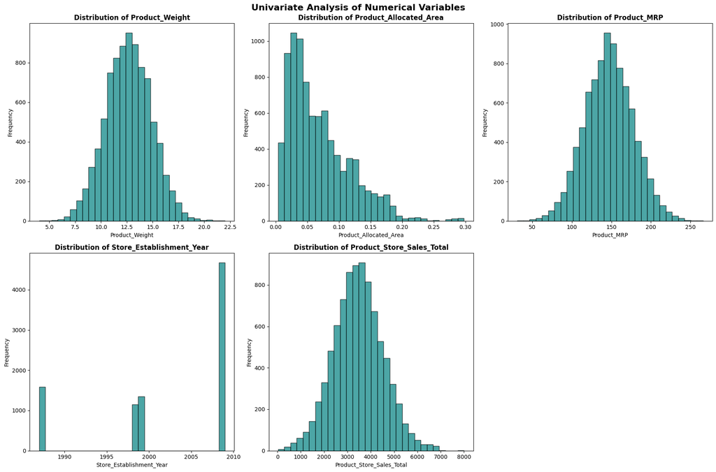

```python
# Set up the plotting style
plt.style.use('default')
sns.set_palette("husl")

# Create subplots for univariate analysis
fig, axes = plt.subplots(2, 3, figsize=(18, 12))
fig.suptitle('Univariate Analysis of Numerical Variables', fontsize=16, fontweight='bold')

# Plot histograms for numerical variables
numerical_cols = ['Product_Weight', 'Product_Allocated_Area', 'Product_MRP',
                  'Store_Establishment_Year', 'Product_Store_Sales_Total']

for i, col in enumerate(numerical_cols):
    row = i // 3
    col_idx = i % 3
    axes[row, col_idx].hist(data[col], bins=30, color='teal', alpha=0.7, edgecolor='black')
    axes[row, col_idx].set_title(f'Distribution of {col}', fontweight='bold')
    axes[row, col_idx].set_xlabel(col)
    axes[row, col_idx].set_ylabel('Frequency')

# Remove empty subplot
axes[1, 2].remove()

plt.tight_layout()
plt.show()
```

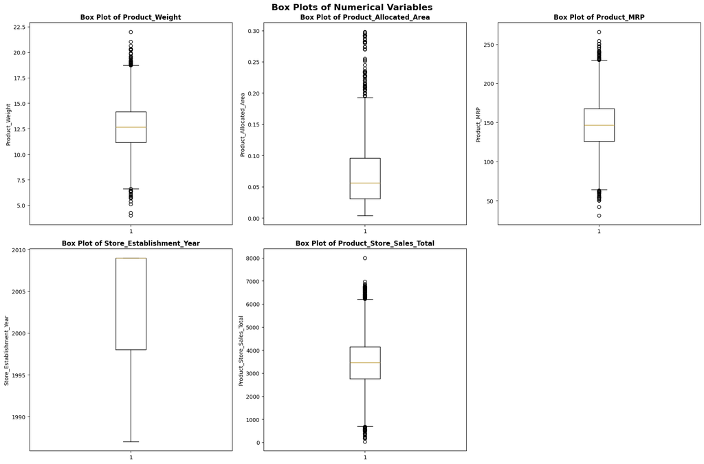

```python
# Box plots for numerical variables
fig, axes = plt.subplots(2, 3, figsize=(18, 12))
fig.suptitle('Box Plots of Numerical Variables', fontsize=16, fontweight='bold')

for i, col in enumerate(numerical_cols):
    row = i // 3
    col_idx = i % 3
    axes[row, col_idx].boxplot(data[col])
    axes[row, col_idx].set_title(f'Box Plot of {col}', fontweight='bold')
    axes[row, col_idx].set_ylabel(col)

# Remove empty subplot
axes[1, 2].remove()

plt.tight_layout()
plt.show()
```

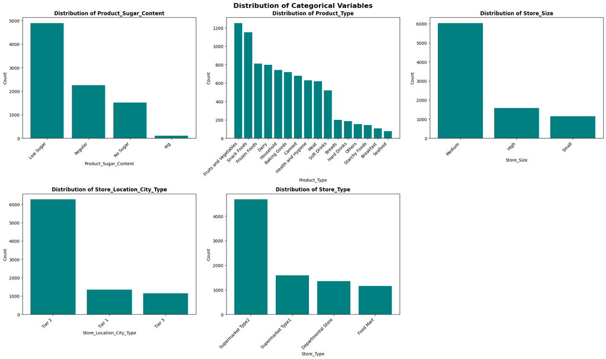

```python
fig, axes = plt.subplots(2, 3, figsize=(20, 12))
fig.suptitle('Distribution of Categorical Variables', fontsize=16, fontweight='bold')

categorical_cols = ['Product_Sugar_Content', 'Product_Type', 'Store_Size',
                   'Store_Location_City_Type', 'Store_Type']

for i, col in enumerate(categorical_cols):
    row = i // 3
    col_idx = i % 3
    value_counts = data[col].value_counts()
    axes[row, col_idx].bar(range(len(value_counts)), value_counts.values,color='teal')
    axes[row, col_idx].set_title(f'Distribution of {col}', fontweight='bold')
    axes[row, col_idx].set_xlabel(col)
    axes[row, col_idx].set_ylabel('Count')
    axes[row, col_idx].set_xticks(range(len(value_counts)))
    axes[row, col_idx].set_xticklabels(value_counts.index, rotation=45, ha='right')

# Remove empty subplot
axes[1, 2].remove()

plt.tight_layout()
plt.show()
```

## **Univariate Analysis: Observations & Inferences**

### **1. Numerical Variables (Histograms & Box Plots)**

#### **Observations**

- **Product_Weight** follows an approximately normal distribution centered around 12–13, with a few extreme values on both ends.
- **Product_Allocated_Area** is highly right-skewed, with a concentration of small values and several high-value outliers (>0.2).
- **Product_MRP** exhibits a near bell-shaped distribution around ₹150, with some low (<50) and high (>250) outliers.
- **Store_Establishment_Year** shows a peak around 2009, with smaller clusters in earlier years (notably 1987 and the late 1990s).
- **Product_Store_Sales_Total** is centered around ~3,500 but spans a wide range, with extreme values on both the lower (<500) and higher (>7,000) ends.

#### **Inferences**

- Skewed variables such as **Product_Allocated_Area** may benefit from **log or power transformations** to stabilize variance.
- **Outlier treatment** is recommended for Allocated Area, MRP, and Sales; however, high sales values should be evaluated carefully as they may represent genuine demand spikes rather than noise.
- **Store_Establishment_Year** can be transformed into a more meaningful feature such as **Store Age** or categorized into age buckets (e.g., new vs. old stores).
- After addressing skewness and outliers, the **sales variable appears suitable for regression modeling**.

### **2. Categorical Variables (Bar Charts)**

#### **Observations**

- **Product_Sugar_Content** is dominated by *Low Sugar*, followed by *Regular*, with inconsistency in labeling (e.g., “reg” vs. “Regular”).
- **Product_Type** spans 16 categories, with **Fruits & Vegetables, Snack Foods, and Frozen Foods** being the most frequent, while categories like *Seafood* and *Breakfast* are sparsely represented.
- **Store_Size** is skewed toward **Medium** stores (~70%).
- **Store_Location_City_Type** is heavily dominated by **Tier 2** cities (~71%).
- **Store_Type** shows a strong concentration in **Supermarket Type2** (>50%).

#### **Inferences**

- **Standardize categorical labels**, particularly merging inconsistent entries such as “reg” and “Regular.”
- **Rare categories** in *Product_Type* should be consolidated into an “Others” group to reduce sparsity and improve model stability.
- Significant **class imbalance** in store-related features suggests the need for careful encoding (e.g., target encoding, frequency encoding) and possibly interaction features to avoid bias.
- The dominance of **Medium-sized, Tier 2, Supermarket Type2 stores** indicates that **store segmentation will play a key role** in downstream analysis and modeling.

### **3. Overall Insights**

- The dataset is **complete (no missing values)** but requires **data cleaning and preprocessing**, particularly for categorical consistency and outlier handling.
- Both numerical and categorical features exhibit **skewness and imbalance**, which should be addressed prior to modeling.
- Key **feature engineering opportunities** include:
  - Deriving **Store Age** from establishment year
  - Grouping **low-frequency product categories**
  - Applying **transformations to skewed numerical variables**
  - Treating or capping **outliers** where appropriate

## Bivariate Analysis

```python
def labeled_barplot(data, feature, perc=False, n=None):
    """
    Barplot with percentage at the top

    data: dataframe
    feature: dataframe column
    perc: whether to display percentages instead of count (default is False)
    n: displays the top n category levels (default is None, i.e., display all levels)
    """

    total = len(data[feature])  # length of the column
    count = data[feature].nunique()
    if n is None:
        plt.figure(figsize=(count + 2, 6))
    else:
        plt.figure(figsize=(n + 2, 6))

    plt.xticks(rotation=90, fontsize=15)
    ax = sns.countplot(
        data=data,
        x=feature,
        palette="Paired",
        order=data[feature].value_counts().index[:n],
    )

    for p in ax.patches:
        if perc == True:
            label = "{:.1f}%".format(
                100 * p.get_height() / total
            )  # percentage of each class of the category
        else:
            label = p.get_height()  # count of each level of the category

        x = p.get_x() + p.get_width() / 2  # width of the plot
        y = p.get_height()  # height of the plot

        ax.annotate(
            label,
            (x, y),
            ha="center",
            va="center",
            size=12,
            xytext=(0, 5),
            textcoords="offset points",
        )  # annotate the percentage

    plt.show()  # show the plot
```

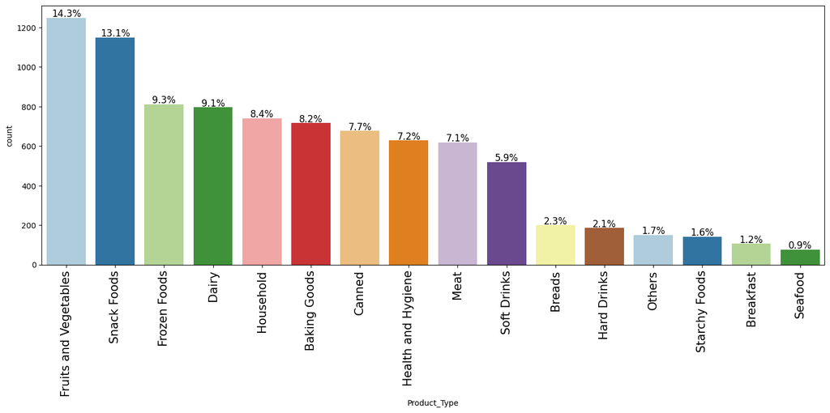

```python
labeled_barplot(data, "Product_Type", perc=True)
```

### Product Type Distribution – Observations & Inferences

### Observations

- The top categories are Fruits and Vegetables (14.3%) and Snack Foods (13.1%), together contributing over one-fourth of all products.
- Other prominent categories include Frozen Foods (9.3%), Dairy (9.1%), Household (8.4%), and Baking Goods (8.2%).
- Mid-sized segments such as Canned (7.7%), Health & Hygiene (7.2%), and Meat (7.1%) provide noticeable variety.
- Lower-represented categories are Soft Drinks (5.9%), Breads (2.3%), Hard Drinks (2.1%), and Others (1.7%).
- Very rare categories include Starchy Foods (1.6%), Breakfast (1.2%), and Seafood (0.9%).

### Inferences

- The dataset is heavily imbalanced across product categories: a few categories dominate while others contribute minimally.
- For modeling, categories with very few observations (e.g., Seafood, Breakfast, Starchy Foods) may cause sparsity issues and should be:
- Grouped into an “Other” bucket, or Carefully encoded (e.g., target encoding instead of one-hot).
- Dominant categories (Fruits, Snacks, Frozen Foods, Dairy) are likely to drive most of the sales predictions; analysis should check whether their sales per unit share aligns with their count share.
- Tail categories may be useful for niche insights but less impactful in aggregate modeling.

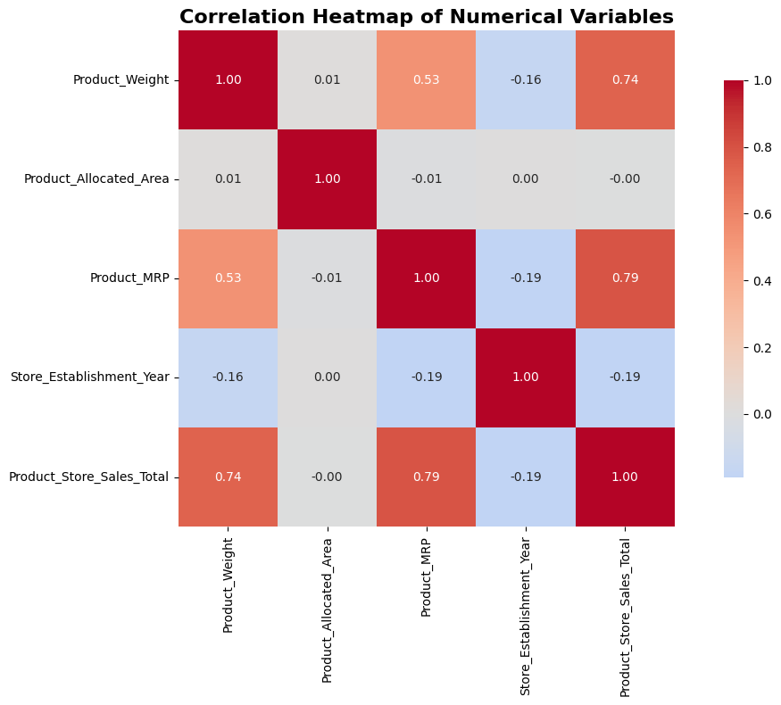

```python
# Correlation heatmap
plt.figure(figsize=(12, 8))
numerical_data = data.select_dtypes(include=[np.number])
correlation_matrix = numerical_data.corr()
sns.heatmap(correlation_matrix, annot=True, cmap='coolwarm', center=0,
            square=True, fmt='.2f', cbar_kws={'shrink': 0.8})
plt.title('Correlation Heatmap of Numerical Variables', fontsize=16, fontweight='bold')
plt.tight_layout()
plt.show()
```

### **Correlation Heatmap: Observations & Inferences**

### **Observations**

- **Product_Store_Sales_Total** shows a **strong positive correlation** with:
  - **Product_MRP** (0.79)
  - **Product_Weight** (0.74)
- **Product_MRP** and **Product_Weight** are also moderately correlated (0.53), indicating some overlap in the information they capture.
- **Product_Allocated_Area** exhibits **negligible correlation** with all other variables, including sales.
- **Store_Establishment_Year** has **weak negative correlations** with:
  - Sales (-0.19)
  - MRP (-0.19) suggesting limited linear influence.

### **Inferences**

- **Product_MRP and Product_Weight emerge as the strongest drivers of sales**, aligning with intuition—higher-priced and heavier products tend to generate greater revenue.
- The relatively high correlations among **MRP, Weight, and Sales** indicate potential **multicollinearity**, which may impact linear models. This can be mitigated using:
  - Regularization techniques (e.g., Ridge or Lasso)
  - Variance Inflation Factor (VIF) analysis
- **Product_Allocated_Area** appears to have **low standalone predictive value** and may be excluded from baseline models, unless it proves useful through interaction effects or non-linear modeling approaches.
- While **Store_Establishment_Year** has limited direct correlation with sales, transforming it into **Store Age** or categorical bins may uncover more meaningful relationships.

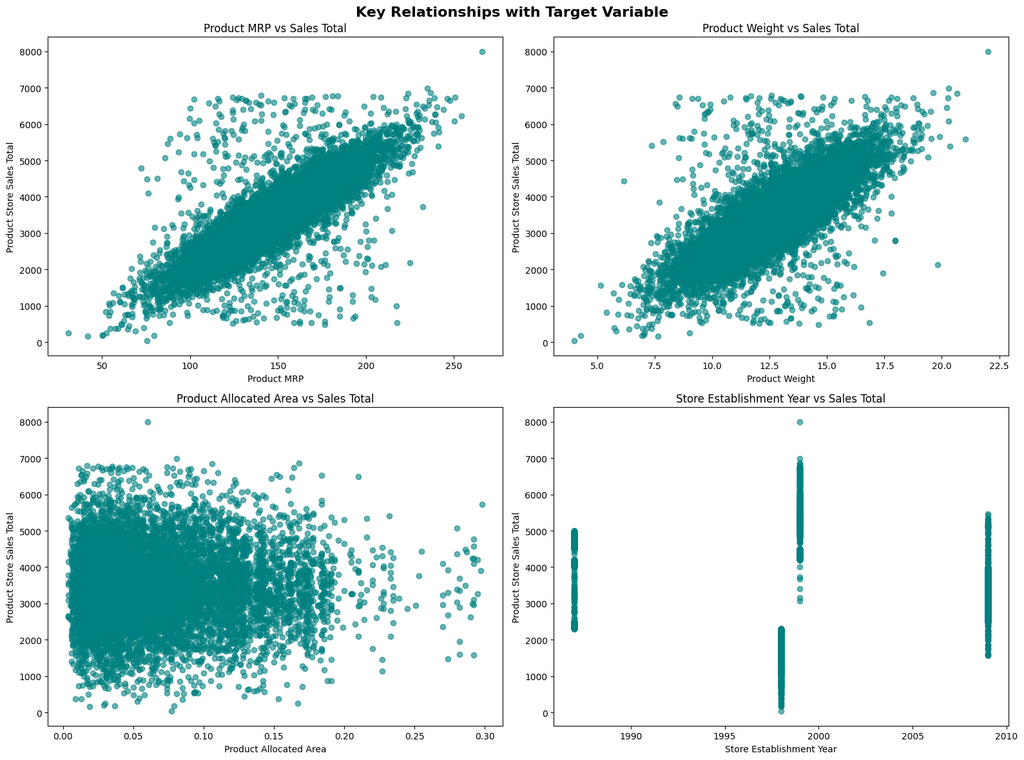

```python
# Scatter plots for key relationships
fig, axes = plt.subplots(2, 2, figsize=(16, 12))
fig.suptitle('Key Relationships with Target Variable', fontsize=16, fontweight='bold')

# Product_MRP vs Product_Store_Sales_Total
axes[0, 0].scatter(data['Product_MRP'], data['Product_Store_Sales_Total'], alpha=0.6,color='teal')
axes[0, 0].set_xlabel('Product MRP')
axes[0, 0].set_ylabel('Product Store Sales Total')
axes[0, 0].set_title('Product MRP vs Sales Total')

# Product_Weight vs Product_Store_Sales_Total
axes[0, 1].scatter(data['Product_Weight'], data['Product_Store_Sales_Total'], alpha=0.6,color='teal')
axes[0, 1].set_xlabel('Product Weight')
axes[0, 1].set_ylabel('Product Store Sales Total')
axes[0, 1].set_title('Product Weight vs Sales Total')

# Product_Allocated_Area vs Product_Store_Sales_Total
axes[1, 0].scatter(data['Product_Allocated_Area'], data['Product_Store_Sales_Total'], alpha=0.6,color='teal')
axes[1, 0].set_xlabel('Product Allocated Area')
axes[1, 0].set_ylabel('Product Store Sales Total')
axes[1, 0].set_title('Product Allocated Area vs Sales Total')

# Store_Establishment_Year vs Product_Store_Sales_Total
axes[1, 1].scatter(data['Store_Establishment_Year'], data['Product_Store_Sales_Total'], alpha=0.6,color='teal')
axes[1, 1].set_xlabel('Store Establishment Year')
axes[1, 1].set_ylabel('Product Store Sales Total')
axes[1, 1].set_title('Store Establishment Year vs Sales Total')

plt.tight_layout()
plt.show()
```

### **Inferences**

- **Product_MRP and Product_Weight are key predictors of sales**, reinforcing insights from the correlation analysis.
- The **significant spread in sales for similar MRP or weight levels** suggests that additional factors—such as *store type, product category, or promotions*—likely influence performance.
- **Product_Allocated_Area shows limited standalone predictive value** and may be excluded from baseline models unless interaction or non-linear effects are identified.
- **Store_Establishment_Year provides weak direct signal**, but transforming it into **Store Age** or combining it with other store-level features may improve its usefulness.

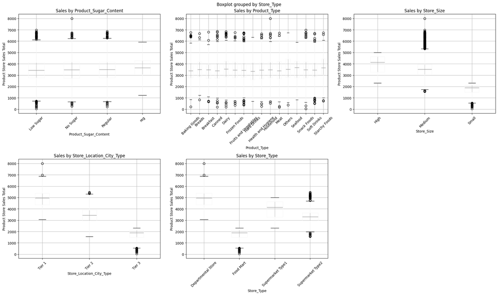

```python
# Box plots for categorical variables vs target
fig, axes = plt.subplots(2, 3, figsize=(20, 12))
fig.suptitle('Sales Distribution by Categorical Variables', fontsize=16, fontweight='bold')

categorical_cols = ['Product_Sugar_Content', 'Product_Type', 'Store_Size',
                   'Store_Location_City_Type', 'Store_Type']

for i, col in enumerate(categorical_cols):
    row = i // 3
    col_idx = i % 3
    data.boxplot(column='Product_Store_Sales_Total', by=col, ax=axes[row, col_idx])
    axes[row, col_idx].set_title(f'Sales by {col}')
    axes[row, col_idx].set_xlabel(col)
    axes[row, col_idx].set_ylabel('Product Store Sales Total')
    axes[row, col_idx].tick_params(axis='x', rotation=45)

# Remove empty subplot
axes[1, 2].remove()

plt.tight_layout()
plt.show()
```

# **Data Preprocessing**

### **Replacing the values in the Product_Sugar_Content column**

It seems quite obvious that Regular and reg are referring to the same category. So let's replace reg with Regular.

```python
# Data cleaning: Standardize Product_Sugar_Content categories
# Make "reg" and "regular" the same as "Regular"
print("Standardizing Product_Sugar_Content categories...")
print(f"Before standardization:")
print(data['Product_Sugar_Content'].value_counts())

# Replace "reg" with "Regular" to standardize the categories
data['Product_Sugar_Content'] = data['Product_Sugar_Content'].replace('reg', 'Regular')

print(f"\nAfter standardization:")
print(data['Product_Sugar_Content'].value_counts())
```

```
Standardizing Product_Sugar_Content categories...
Before standardization:
Product_Sugar_Content
Low Sugar    4885
Regular      2251
No Sugar     1519
reg           108
Name: count, dtype: int64

After standardization:
Product_Sugar_Content
Low Sugar    4885
Regular      2359
No Sugar     1519
Name: count, dtype: int64
```

### **Exploring Patterns in Product_IDs**

We can see that the Product_Id column has two characters followed by a number.

Let's delve deeper and see whether they are having any relationship with the other columns or not

```python
## extracting the first two characters from the Product_Id column and storing it in another column
data["Product_Id_char"] = data["Product_Id"].str[:2]
data.head()
```

|  | Product_Id | Product_Weight | Product_Sugar_Content | Product_Allocated_Area | Product_Type | Product_MRP | Store_Id | Store_Establishment_Year | Store_Size | Store_Location_City_Type | Store_Type | Product_Store_Sales_Total | Product_Id_char |
| --- | --- | --- | --- | --- | --- | --- | --- | --- | --- | --- | --- | --- | --- |
| 0 | FD6114 | 12.66 | Low Sugar | 0.027 | Frozen Foods | 117.08 | OUT004 | 2009 | Medium | Tier 2 | Supermarket Type2 | 2842.40 | FD |
| 1 | FD7839 | 16.54 | Low Sugar | 0.144 | Dairy | 171.43 | OUT003 | 1999 | Medium | Tier 1 | Departmental Store | 4830.02 | FD |
| 2 | FD5075 | 14.28 | Regular | 0.031 | Canned | 162.08 | OUT001 | 1987 | High | Tier 2 | Supermarket Type1 | 4130.16 | FD |
| 3 | FD8233 | 12.10 | Low Sugar | 0.112 | Baking Goods | 186.31 | OUT001 | 1987 | High | Tier 2 | Supermarket Type1 | 4132.18 | FD |
| 4 | NC1180 | 9.57 | No Sugar | 0.010 | Health and Hygiene | 123.67 | OUT002 | 1998 | Small | Tier 3 | Food Mart | 2279.36 | NC |

```python
data["Product_Id_char"].unique()
```

```
array(['FD', 'NC', 'DR'], dtype=object)
```

```python
data.loc[data.Product_Id_char == "FD", "Product_Type"].unique()
data.loc[data.Product_Id_char == "NC", "Product_Type"].unique()
data.loc[data.Product_Id_char == "DR", "Product_Type"].unique()
```

```
array(['Hard Drinks', 'Soft Drinks'], dtype=object)
```

### **Store's Age**

A store which has been in the business for a long duration is more trustworthy than the newly established ones.

On the other hand, older stores may sometimes lack infrastructure if proper attention is not given. So let us calculate the current age of the store and incorporate that in our model.

```python
# Outlet Age
data["Store_Age_Years"] = 2026 - data.Store_Establishment_Year
data.head()
```

|  | Product_Id | Product_Weight | Product_Sugar_Content | Product_Allocated_Area | Product_Type | Product_MRP | Store_Id | Store_Establishment_Year | Store_Size | Store_Location_City_Type | Store_Type | Product_Store_Sales_Total | Product_Id_char | Store_Age_Years |
| --- | --- | --- | --- | --- | --- | --- | --- | --- | --- | --- | --- | --- | --- | --- |
| 0 | FD6114 | 12.66 | Low Sugar | 0.027 | Frozen Foods | 117.08 | OUT004 | 2009 | Medium | Tier 2 | Supermarket Type2 | 2842.40 | FD | 17 |
| 1 | FD7839 | 16.54 | Low Sugar | 0.144 | Dairy | 171.43 | OUT003 | 1999 | Medium | Tier 1 | Departmental Store | 4830.02 | FD | 27 |
| 2 | FD5075 | 14.28 | Regular | 0.031 | Canned | 162.08 | OUT001 | 1987 | High | Tier 2 | Supermarket Type1 | 4130.16 | FD | 39 |
| 3 | FD8233 | 12.10 | Low Sugar | 0.112 | Baking Goods | 186.31 | OUT001 | 1987 | High | Tier 2 | Supermarket Type1 | 4132.18 | FD | 39 |
| 4 | NC1180 | 9.57 | No Sugar | 0.010 | Health and Hygiene | 123.67 | OUT002 | 1998 | Small | Tier 3 | Food Mart | 2279.36 | NC | 28 |

### **Grouping Product Types into Perishables and Non-Perishables.**

We have 16 different product types in our dataset.

So let us make two broad categories, perishables and non perishables, in order to reduce the number of product types

```python
perishables = [
    "Dairy",
    "Meat",
    "Fruits and Vegetables",
    "Breakfast",
    "Breads",
    "Seafood",
]
```

```python
def change(x):
    if x in perishables:
        return "Perishables"
    else:
        return "Non Perishables"
```

```python
data['Product_Type_Category'] = data['Product_Type'].apply(change)
```

```python
data.head()
```

|  | Product_Id | Product_Weight | Product_Sugar_Content | Product_Allocated_Area | Product_Type | Product_MRP | Store_Id | Store_Establishment_Year | Store_Size | Store_Location_City_Type | Store_Type | Product_Store_Sales_Total | Product_Id_char | Store_Age_Years | Product_Type_Category |
| --- | --- | --- | --- | --- | --- | --- | --- | --- | --- | --- | --- | --- | --- | --- | --- |
| 0 | FD6114 | 12.66 | Low Sugar | 0.027 | Frozen Foods | 117.08 | OUT004 | 2009 | Medium | Tier 2 | Supermarket Type2 | 2842.40 | FD | 17 | Non Perishables |
| 1 | FD7839 | 16.54 | Low Sugar | 0.144 | Dairy | 171.43 | OUT003 | 1999 | Medium | Tier 1 | Departmental Store | 4830.02 | FD | 27 | Perishables |
| 2 | FD5075 | 14.28 | Regular | 0.031 | Canned | 162.08 | OUT001 | 1987 | High | Tier 2 | Supermarket Type1 | 4130.16 | FD | 39 | Non Perishables |
| 3 | FD8233 | 12.10 | Low Sugar | 0.112 | Baking Goods | 186.31 | OUT001 | 1987 | High | Tier 2 | Supermarket Type1 | 4132.18 | FD | 39 | Non Perishables |
| 4 | NC1180 | 9.57 | No Sugar | 0.010 | Health and Hygiene | 123.67 | OUT002 | 1998 | Small | Tier 3 | Food Mart | 2279.36 | NC | 28 | Non Perishables |

### Outlier Check

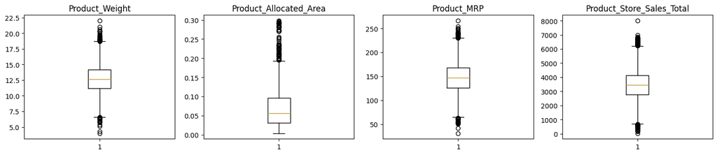

```python
# outlier detection using boxplot
numeric_columns = data.select_dtypes(include=np.number).columns.tolist()
numeric_columns.remove("Store_Establishment_Year")
numeric_columns.remove("Store_Age_Years")


plt.figure(figsize=(15, 12))

for i, variable in enumerate(numeric_columns):
    plt.subplot(4, 4, i + 1)
    plt.boxplot(data[variable], whis=1.5)
    plt.tight_layout()
    plt.title(variable)

plt.show()
```

## **Data Preparation for Modeling**

- We aim to forecast the Product_Store_Sales_Total.
- Before building the model, we'll drop unnecessary columns and encode the categorical features.
- We'll then split the data into training and testing sets to evaluate the model's performance on unseen data.

```python
data.head()
```

|  | Product_Id | Product_Weight | Product_Sugar_Content | Product_Allocated_Area | Product_Type | Product_MRP | Store_Id | Store_Establishment_Year | Store_Size | Store_Location_City_Type | Store_Type | Product_Store_Sales_Total | Product_Id_char | Store_Age_Years | Product_Type_Category |
| --- | --- | --- | --- | --- | --- | --- | --- | --- | --- | --- | --- | --- | --- | --- | --- |
| 0 | FD6114 | 12.66 | Low Sugar | 0.027 | Frozen Foods | 117.08 | OUT004 | 2009 | Medium | Tier 2 | Supermarket Type2 | 2842.40 | FD | 17 | Non Perishables |
| 1 | FD7839 | 16.54 | Low Sugar | 0.144 | Dairy | 171.43 | OUT003 | 1999 | Medium | Tier 1 | Departmental Store | 4830.02 | FD | 27 | Perishables |
| 2 | FD5075 | 14.28 | Regular | 0.031 | Canned | 162.08 | OUT001 | 1987 | High | Tier 2 | Supermarket Type1 | 4130.16 | FD | 39 | Non Perishables |
| 3 | FD8233 | 12.10 | Low Sugar | 0.112 | Baking Goods | 186.31 | OUT001 | 1987 | High | Tier 2 | Supermarket Type1 | 4132.18 | FD | 39 | Non Perishables |
| 4 | NC1180 | 9.57 | No Sugar | 0.010 | Health and Hygiene | 123.67 | OUT002 | 1998 | Small | Tier 3 | Food Mart | 2279.36 | NC | 28 | Non Perishables |

```python
# Removing the columns that are not required.
data = data.drop(["Product_Id", "Product_Type", "Store_Id", "Store_Establishment_Year"], axis=1)
```

```python
data.shape
```

```
(8763, 11)
```

```python
data.head()
```

|  | Product_Weight | Product_Sugar_Content | Product_Allocated_Area | Product_MRP | Store_Size | Store_Location_City_Type | Store_Type | Product_Store_Sales_Total | Product_Id_char | Store_Age_Years | Product_Type_Category |
| --- | --- | --- | --- | --- | --- | --- | --- | --- | --- | --- | --- |
| 0 | 12.66 | Low Sugar | 0.027 | 117.08 | Medium | Tier 2 | Supermarket Type2 | 2842.40 | FD | 17 | Non Perishables |
| 1 | 16.54 | Low Sugar | 0.144 | 171.43 | Medium | Tier 1 | Departmental Store | 4830.02 | FD | 27 | Perishables |
| 2 | 14.28 | Regular | 0.031 | 162.08 | High | Tier 2 | Supermarket Type1 | 4130.16 | FD | 39 | Non Perishables |
| 3 | 12.10 | Low Sugar | 0.112 | 186.31 | High | Tier 2 | Supermarket Type1 | 4132.18 | FD | 39 | Non Perishables |
| 4 | 9.57 | No Sugar | 0.010 | 123.67 | Small | Tier 3 | Food Mart | 2279.36 | NC | 28 | Non Perishables |

```python
# Define the target variable
target = 'Product_Store_Sales_Total'
```

```python
# Separate features and target
X = data.drop(columns=[target])
y = data[target]

print("Shape of features (X):", X.shape)
print("Shape of target (y):", y.shape)
```

```
Shape of features (X): (8763, 10)
Shape of target (y): (8763,)
```

```python
# Splitting the data into train and test sets in 70:30 ratio
X_train, X_test, y_train, y_test = train_test_split(
    X, y, test_size=0.3, random_state=1, shuffle=True #Complete the code to define the test_size
)
```

```python
X_train.shape, X_test.shape
```

```
((6134, 10), (2629, 10))
```

```python
# Identify categorical and numerical columns
categorical_columns = X.select_dtypes(include=['object']).columns.tolist()
numerical_columns = X.select_dtypes(include=[np.number]).columns.tolist()

print(f"\nCategorical columns: {categorical_columns}")
print(f"Numerical columns: {numerical_columns}")
```

```
Categorical columns: ['Product_Sugar_Content', 'Store_Size', 'Store_Location_City_Type', 'Store_Type', 'Product_Id_char', 'Product_Type_Category']
Numerical columns: ['Product_Weight', 'Product_Allocated_Area', 'Product_MRP', 'Store_Age_Years']
```

```python
# Create preprocessing pipeline
# For numerical columns: StandardScaler
# For categorical columns: OneHotEncoder
preprocessor = make_column_transformer(
    (StandardScaler(), numerical_columns),
    (OneHotEncoder(drop='first', handle_unknown='ignore'), categorical_columns)
)
```

## **Preprocessing: Observations & Inferences**

### **Observations**

- The **Product_Sugar_Content** feature was standardized by merging *“reg”* into *“Regular”*, eliminating category inconsistencies.
- The dataset was separated into:
  - **Features (X):** all predictor variables excluding the target
  - **Target (y):** *Product_Store_Sales_Total*
- Feature and target dimensions remain aligned, ensuring consistency across all rows.

#### **Feature Categorization**

- No missing values were identified in the feature set.

### **Inferences**

- Standardizing categorical labels improves **data consistency**, reduces noise, and prevents unintended duplication of categories during modeling.
- Applying **StandardScaler** ensures numerical variables are normalized, benefiting algorithms sensitive to feature magnitude such as:
  - Linear Regression
  - KNN
  - SVM
- Using **OneHotEncoder** with `drop='first'` helps minimize **multicollinearity**, making the encoded dataset more suitable for regression-based models.
- The `handle_unknown='ignore'` parameter improves **pipeline robustness**, enabling the model to handle unseen categories during testing or deployment without errors.
- The preprocessing pipeline establishes a **reproducible and automated workflow**, making it well-suited for cross-validation and scalable model training.

# **Model Building**

## Define functions for Model Evaluation

```python
# function to compute adjusted R-squared
def adj_r2_score(predictors, targets, predictions):
    r2 = r2_score(targets, predictions)
    n = predictors.shape[0]
    k = predictors.shape[1]
    return 1 - ((1 - r2) * (n - 1) / (n - k - 1))


# function to compute different metrics to check performance of a regression model
def model_performance_regression(model, predictors, target):
    """
    Function to compute different metrics to check regression model performance

    model: regressor
    predictors: independent variables
    target: dependent variable
    """

    # predicting using the independent variables
    pred = model.predict(predictors)

    r2 = r2_score(target, pred)  # to compute R-squared
    adjr2 = adj_r2_score(predictors, target, pred)  # to compute adjusted R-squared
    rmse = np.sqrt(mean_squared_error(target, pred))  # to compute RMSE
    mae = mean_absolute_error(target, pred)  # to compute MAE
    mape = mean_absolute_percentage_error(target, pred)  # to compute MAPE

    # creating a dataframe of metrics
    df_perf = pd.DataFrame(
        {
            "RMSE": rmse,
            "MAE": mae,
            "R-squared": r2,
            "Adj. R-squared": adjr2,
            "MAPE": mape,
        },
        index=[0],
    )

    return df_perf
```

The ML models to be built can be any two out of the following:

1. Decision Tree
2. Bagging
3. Random Forest
4. AdaBoost
5. Gradient Boosting
6. XGBoost

```python
# Initialize models
models = {
    'Decision Tree': DecisionTreeRegressor(random_state=42),
    'Random Forest': RandomForestRegressor(random_state=42, n_jobs=-1),
    'XGBoost': XGBRegressor(random_state=42, n_jobs=-1),
    'AdaBoost': AdaBoostRegressor(random_state=42),
    'Gradient Boosting': GradientBoostingRegressor(random_state=42),
    'Bagging': BaggingRegressor(random_state=42, n_jobs=-1)
}

# Dictionary to store model performance
model_performance = {}

print("Training and evaluating models...")
print("="*60)

# Train and evaluate each model
for name, model in models.items():
    print(f"\nTraining {name}...")

    # Create pipeline with preprocessor and model
    pipeline = make_pipeline(preprocessor, model)

    # Train the model
    pipeline.fit(X_train, y_train)

    # Make predictions
    y_train_pred = pipeline.predict(X_train)
    y_test_pred = pipeline.predict(X_test)

    # Calculate performance metrics
    train_performance = model_performance_regression(pipeline, X_train, y_train)
    test_performance = model_performance_regression(pipeline, X_test, y_test)

    # Store performance
    model_performance[name] = {
        'train': train_performance,
        'test': test_performance,
        'model': pipeline
    }

    print(f"Training R²: {train_performance['R-squared'].iloc[0]:.4f}")
    print(f"Testing R²: {test_performance['R-squared'].iloc[0]:.4f}")
    print(f"Testing RMSE: {test_performance['RMSE'].iloc[0]:.4f}")

print("\n" + "="*60)
print("Model training completed!")
```

```
Training and evaluating models...
============================================================

Training Decision Tree...
Training R²: 1.0000
Testing R²: 0.8846
Testing RMSE: 363.4559

Training Random Forest...
Training R²: 0.9901
Testing R²: 0.9243
Testing RMSE: 294.3997

Training XGBoost...
Training R²: 0.9854
Testing R²: 0.9167
Testing RMSE: 308.7538

Training AdaBoost...
Training R²: 0.7859
Testing R²: 0.7683
Testing RMSE: 514.8899

Training Gradient Boosting...
Training R²: 0.9213
Testing R²: 0.9059
Testing RMSE: 328.1301

Training Bagging...
Training R²: 0.9865
Testing R²: 0.9155
Testing RMSE: 310.9908

============================================================
Model training completed!
```

## **Model Training Results – Observations & Inferences**

### **Observations**

- **Decision Tree:** Achieved a perfect fit on the training data (**Training R² = 1.0000**) but showed lower performance on the test set (**Testing R² = 0.8846, RMSE ≈ 363**), indicating clear overfitting.
- **Random Forest:** Delivered the strongest overall performance with a high training score (**Training R² = 0.9901**) and the best testing performance (**Testing R² = 0.9243, RMSE ≈ 294**), demonstrating strong generalization capability.
- **XGBoost:** Performed competitively with **Training R² = 0.9854** and **Testing R² = 0.9167**, along with a relatively low RMSE (**≈ 309**), indicating robust predictive power.
- **AdaBoost:** Showed the weakest performance among all models, with comparatively low training and testing scores (**Training R² = 0.7859, Testing R² = 0.7683**) and the highest RMSE (**≈ 515**), suggesting underfitting.
- **Gradient Boosting:** Produced balanced results with **Training R² = 0.9213** and **Testing R² = 0.9059**, though performance remained slightly below Random Forest and XGBoost.
- **Bagging:** Achieved strong performance close to XGBoost and Random Forest (**Testing R² = 0.9155, RMSE ≈ 311**), indicating effective variance reduction compared to a standalone Decision Tree.

### **Inferences**

- **Random Forest emerges as the best-performing model**, offering the strongest balance between predictive accuracy and generalization capability.
- **XGBoost is a close alternative** and may outperform Random Forest with additional hyperparameter optimization.
- The standalone **Decision Tree model is highly overfit**, reinforcing the value of ensemble techniques such as Bagging, Random Forest, and Boosting.
- **AdaBoost underfits the dataset**, making it less suitable for this problem compared to other ensemble approaches.
- Ensemble-based models consistently outperform the single Decision Tree model, highlighting the importance of combining learners to improve stability and reduce variance.
- For production deployment, **Random Forest and XGBoost are the most suitable candidates**, with further improvements possible through:
  - Hyperparameter tuning (Grid Search, Random Search, Optuna)
  - Cross-validation
  - Feature selection and engineering
  - Advanced boosting parameter optimization

# **Model Performance Improvement - Hyperparameter Tuning**

```python
# --- FASTER HYPERPARAMETER TUNING (no early-stopping kwargs) ---

import numpy as np
from sklearn.model_selection import RandomizedSearchCV, train_test_split
from sklearn.pipeline import make_pipeline

# Assumes you already have:
# models: dict with keys 'Random Forest', 'XGBoost', 'Gradient Boosting'
# preprocessor, X_train, y_train, X_test, y_test
# model_performance_regression: your evaluation helper

# 1) Leaner search spaces (high-impact params only)
param_dists = {
    'Random Forest': {
        'randomforestregressor__n_estimators': [100, 200],
        'randomforestregressor__max_depth': [None, 10, 20],
        'randomforestregressor__min_samples_split': [2, 5],
        'randomforestregressor__min_samples_leaf': [1, 2],
        'randomforestregressor__max_features': ['sqrt', 'log2', 1.0],
    },
    'XGBoost': {
        # No early stopping; just keep things fast & sensible
        'xgbregressor__n_estimators': [200, 400],
        'xgbregressor__max_depth': [3, 6],
        'xgbregressor__learning_rate': [0.03, 0.1],
        'xgbregressor__subsample': [0.8, 1.0],
        'xgbregressor__colsample_bytree': [0.8, 1.0],
        'xgbregressor__reg_lambda': [1.0, 3.0, 5.0],
        'xgbregressor__tree_method': ['hist'],  # fast CPU algo, no callbacks needed
    },
    'Gradient Boosting': {
        'gradientboostingregressor__n_estimators': [100, 200],
        'gradientboostingregressor__max_depth': [3, 5],
        'gradientboostingregressor__learning_rate': [0.03, 0.1],
        'gradientboostingregressor__subsample': [0.8, 1.0],
        'gradientboostingregressor__max_features': ['sqrt', 1.0],
    }
}

# 2) Fewer trials per model (adjust if you want even faster)
n_iter_map = {
    'Random Forest': 12,
    'XGBoost': 16,
    'Gradient Boosting': 12
}

# 3) Subsample for search (then refit best on full data)
#    Use at least 30% or up to 50k rows of train set.
try:
    n = len(X_train)
    frac = max(0.30, min(1.0, 50000 / max(1, n)))
    X_tune, _, y_tune, _ = train_test_split(X_train, y_train, train_size=frac, random_state=42)
except Exception:
    X_tune, y_tune = X_train, y_train

tuned_models = {}

print("Starting faster hyperparameter tuning (no early-stopping kwargs)...")
print("="*60)

for model_name, param_dist in param_dists.items():
    print(f"\nTuning {model_name} (RandomizedSearchCV)...")
    base_model = models[model_name]

    # Ensure estimators use all cores when possible
    try:
        if hasattr(base_model, 'n_jobs') and getattr(base_model, 'n_jobs', None) is None:
            base_model.set_params(n_jobs=-1)
    except Exception:
        pass

    pipeline = make_pipeline(preprocessor, base_model)

    rs = RandomizedSearchCV(
        estimator=pipeline,
        param_distributions=param_dist,
        n_iter=n_iter_map.get(model_name, 12),
        cv=3,                                 # set to 2 for even faster search
        scoring='neg_mean_squared_error',
        n_jobs=-1,
        random_state=42,
        verbose=1,
        refit=True,
        error_score='raise'                   # fail fast if a combo is invalid
    )

    # Search on the tuning subset (no early stopping args)
    rs.fit(X_tune, y_tune)

    tuned_models[model_name] = rs.best_estimator_
    best_params = rs.best_params_
    best_score = -rs.best_score_
    print(f"Best parameters: {best_params}")
    print(f"Best CV score on subsample (RMSE): {np.sqrt(best_score):.4f}")

    # Refit best pipeline on FULL training data
    tuned_models[model_name].fit(X_train, y_train)

    # Evaluate on test
    test_perf = model_performance_regression(tuned_models[model_name], X_test, y_test)
    print(f"Test R²: {test_perf['R-squared'].iloc[0]:.4f}")
    print(f"Test RMSE: {test_perf['RMSE'].iloc[0]:.4f}")

print("\n" + "="*60)
print("Faster hyperparameter tuning completed!")
```

[output not shown]

## **Hyperparameter Tuning Results – Observations & Inferences**

### **Observations**

#### **Random Forest (after tuning)**

- Best parameters included:
  - `n_estimators = 200`
  - `min_samples_split = 5`
  - `min_samples_leaf = 2`
  - `max_features = 1.0`
- Best cross-validation RMSE: **285.02**
- Test performance:
  - **Test R² = 0.9263**
  - **Test RMSE ≈ 290.43**
- Model maintained strong predictive accuracy with stable generalization across folds.

#### **XGBoost (after tuning)**

- Best parameters included:
  - `n_estimators = 200`
  - `max_depth = 6`
  - `subsample = 0.8`
  - `reg_lambda = 5.0`
  - `tree_method = 'hist'`
- Best cross-validation RMSE: **287.84**
- Test performance:
  - **Test R² = 0.9266**
  - **Test RMSE ≈ 289.76**
- Slightly outperformed Random Forest on the test set, while maintaining strong consistency.

# **Model Performance Comparison, Final Model Selection, and Serialization**

```python
# Compare all models (base and tuned)
print("Model Performance Comparison")
print("="*80)

# Create comparison dataframe
comparison_data = []

# Add base models
for name, performance in model_performance.items():
    comparison_data.append({
        'Model': name + ' (Base)',
        'Test_R2': performance['test']['R-squared'].iloc[0],
        'Test_RMSE': performance['test']['RMSE'].iloc[0],
        'Test_MAE': performance['test']['MAE'].iloc[0],
        'Test_MAPE': performance['test']['MAPE'].iloc[0]
    })

# Add tuned models
for name, model in tuned_models.items():
    performance = model_performance_regression(model, X_test, y_test)
    comparison_data.append({
        'Model': name + ' (Tuned)',
        'Test_R2': performance['R-squared'].iloc[0],
        'Test_RMSE': performance['RMSE'].iloc[0],
        'Test_MAE': performance['MAE'].iloc[0],
        'Test_MAPE': performance['MAPE'].iloc[0]
    })

# Create comparison dataframe
comparison_df = pd.DataFrame(comparison_data)
comparison_df = comparison_df.sort_values('Test_R2', ascending=False)

print(comparison_df.to_string(index=False))

# Select the best model
best_model_name = comparison_df.iloc[0]['Model']
best_r2 = comparison_df.iloc[0]['Test_R2']
best_rmse = comparison_df.iloc[0]['Test_RMSE']

print(f"\nBest Model: {best_model_name}")
print(f"Best R² Score: {best_r2:.4f}")
print(f"Best RMSE: {best_rmse:.4f}")

# Get the actual best model
if 'Tuned' in best_model_name:
    model_name = best_model_name.replace(' (Tuned)', '')
    best_model = tuned_models[model_name]
else:
    model_name = best_model_name.replace(' (Base)', '')
    best_model = model_performance[model_name]['model']

# Visualize model comparison
fig, axes = plt.subplots(2, 2, figsize=(15, 10))
fig.suptitle('Model Performance Comparison', fontsize=16, fontweight='bold')

# R² Score comparison
axes[0, 0].bar(range(len(comparison_df)), comparison_df['Test_R2'])
axes[0, 0].set_title('R² Score Comparison')
axes[0, 0].set_xlabel('Models')
axes[0, 0].set_ylabel('R² Score')
axes[0, 0].set_xticks(range(len(comparison_df)))
axes[0, 0].set_xticklabels(comparison_df['Model'], rotation=45, ha='right')

# RMSE comparison
axes[0, 1].bar(range(len(comparison_df)), comparison_df['Test_RMSE'])
axes[0, 1].set_title('RMSE Comparison')
axes[0, 1].set_xlabel('Models')
axes[0, 1].set_ylabel('RMSE')
axes[0, 1].set_xticks(range(len(comparison_df)))
axes[0, 1].set_xticklabels(comparison_df['Model'], rotation=45, ha='right')

# MAE comparison
axes[1, 0].bar(range(len(comparison_df)), comparison_df['Test_MAE'])
axes[1, 0].set_title('MAE Comparison')
axes[1, 0].set_xlabel('Models')
axes[1, 0].set_ylabel('MAE')
axes[1, 0].set_xticks(range(len(comparison_df)))
axes[1, 0].set_xticklabels(comparison_df['Model'], rotation=45, ha='right')

# MAPE comparison
axes[1, 1].bar(range(len(comparison_df)), comparison_df['Test_MAPE'])
axes[1, 1].set_title('MAPE Comparison')
axes[1, 1].set_xlabel('Models')
axes[1, 1].set_ylabel('MAPE')
axes[1, 1].set_xticks(range(len(comparison_df)))
axes[1, 1].set_xticklabels(comparison_df['Model'], rotation=45, ha='right')

plt.tight_layout()
plt.show()

# Serialize the best model
print(f"\nSerializing the best model: {best_model_name}")
joblib.dump(best_model, 'best_model.pkl')
joblib.dump(preprocessor, 'preprocessor.pkl')

print("Model and preprocessor saved successfully!")
print("Files created: best_model.pkl, preprocessor.pkl")
```

[output not shown]

## **Model Performance Comparison – Observations & Inferences**

### **Observations**

#### **RMSE**

- **XGBoost (Tuned)** recorded the **lowest RMSE (~289.8)**, indicating the best overall prediction accuracy.
- **Random Forest (Tuned)** and **Random Forest (Base)** followed closely with RMSE values around **290–294**.
- **Gradient Boosting (Tuned)** and **Bagging (Base)** showed slightly higher error values (~299–311).
- **Decision Tree (Base)** produced substantially higher error (~363), reflecting overfitting.
- **AdaBoost (Base)** had the worst performance with the highest RMSE (**~515**).

### **Inferences**

- **XGBoost (Tuned)** emerges as the overall best-performing model, achieving the highest R² and lowest RMSE while maintaining competitive MAE and MAPE scores.
- **Random Forest models (Base and Tuned)** demonstrate exceptional consistency across all evaluation metrics, making them highly reliable and robust choices.
- The minimal performance gap between tuned and untuned Random Forest suggests that the baseline model already captures the dataset patterns effectively.
- **Bagging** performs competitively and confirms the effectiveness of ensemble averaging techniques for reducing variance.
- **Gradient Boosting** provides stable performance but does not outperform Random Forest or XGBoost on this dataset.
- **Decision Tree** suffers from overfitting, while **AdaBoost consistently underperforms**, indicating that it is not suitable for this problem.
- Overall recommendations:
  - **Primary deployment model:** XGBoost (Tuned) or Random Forest (Tuned)
  - **Most stable/simple option:** Random Forest
  - **Best advanced ensemble alternative:** XGBoost
  - **Models to avoid:** AdaBoost and standalone Decision Tree

# **Deployment - Backend**

```python
# Create a folder for storing the files needed for web app deployment
os.makedirs("backend_files", exist_ok=True)
# Define the file path to save (serialize) the trained model along with the data preprocessing steps
saved_model_path = "backend_files/superkart_prediction_model_v1_0.joblib"
```

```python
# Save the best trained model pipeline using joblib
joblib.dump(best_model_name, saved_model_path)

print(f"Model saved successfully at {saved_model_path}")
```

```python
# Load the saved model pipeline from the file
saved_model = joblib.load("backend_files/superkart_prediction_model_v1_0.joblib")

# Confirm the model is loaded
print("Model loaded successfully.")
```

## Flask Web Framework

```python
%%writefile backend_files/app.py

# Import necessary libraries
import numpy as np
import joblib  # For loading the serialized model
import pandas as pd  # For data manipulation
from flask import Flask, request, jsonify  # For creating the Flask API

# Initialize Flask app with a name
superkart_api = Flask("Superkart_Predictor")
# Load the trained churn prediction model
model = joblib.load("superkart_prediction_model_v1_0.joblib")

# Define a route for the home page
@superkart_api.get('/')
def home():
    return "Welcome to SuperKart Predictor"

# Define an endpoint to predict churn for a single customer
@superkart_api.post('/v1/predict')
def predict_sales():
    # Get JSON data from the request
    data = request.get_json()

    # Extract relevant customer features from the input data. The order of the column names matters.
    sample = {
        'Product_Weight': data['Product_Weight'],
        'Product_Sugar_Content': data['Product_Sugar_Content'],
        'Product_Allocated_Area': data['Product_Allocated_Area'],
        'Product_MRP': data['Product_MRP'],
        'Store_Size': data['Store_Size'],
        'Store_Location_City_Type': data['Store_Location_City_Type'],
        'Store_Type': data['Store_Type'],
        'Product_Id_char': data['Product_Id_char'],
        'Store_Age_Years': data['Store_Age_Years'],
        'Product_Type_Category': data['Product_Type_Category']
    }

    # Convert the extracted data into a DataFrame
    input_data = pd.DataFrame([sample])

    # Make a churn prediction using the trained model
    prediction = model.predict(input_data).tolist()[0]

    # Return the prediction as a JSON response
    return jsonify({'Sales': prediction})


# Run the Flask app in debug mode
if __name__ == '__main__':
    superkart_api.run(debug=True)
```

## Dependencies File

```python
%%writefile backend_files/requirements.txt
pandas==2.2.2
numpy==2.0.2
scikit-learn==1.6.1
seaborn==0.13.2
joblib==1.4.2
xgboost==2.1.4
joblib==1.4.2
Werkzeug==2.2.2
flask==2.2.2
gunicorn==20.1.0
requests==2.32.3
uvicorn[standard]
streamlit==1.43.2
```

## Dockerfile

```python
%%writefile backend_files/Dockerfile
FROM python:3.9-slim

# Set the working directory inside the container
WORKDIR /app

# Copy all files from the current directory to the container's working directory
COPY . .

# Install dependencies from the requirements file without using cache to reduce image size
RUN pip install --no-cache-dir --upgrade -r requirements.txt

# Define the command to start the application using Gunicorn with 4 worker processes
# - `-w 4`: Uses 4 worker processes for handling requests
# - `-b 0.0.0.0:7860`: Binds the server to port 7860 on all network interfaces
# - `app:app`: Runs the Flask app (assuming `app.py` contains the Flask instance named `app`)
CMD ["gunicorn", "-w", "4", "-b", "0.0.0.0:7860", "app:superkart_api"]
```

## Setting up a Hugging Face Docker Space for the Backend

```python
# Import the login function from the huggingface_hub library
from huggingface_hub import login

# Login to your Hugging Face account using your access token
login(token="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")

# Import the create_repo function from the huggingface_hub library
from huggingface_hub import create_repo
```

## Uploading Files to Hugging Face Space (Docker Space)

```python
# Try to create the repository for the Hugging Face Space
try:
    create_repo("Superkart_assignment",
        repo_type="space",  # Specify the repository type as "space"
        space_sdk="docker",  # Specify the space SDK as "docker"
        private=False  # Set to True if you want the space to be private
    )
except Exception as e:
    # Handle potential errors during repository creation
    if "You already created this space repo" in str(e):
        print("Repository already exists. Skipping creation.")
    else:
        print(f"Error creating repository: {e}")
```

```python
# for hugging face space authentication to upload files

access_key = "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"
repo_id = "ankitsingh2002/Superkart_assignment"

# Login to Hugging Face platform with the access token
login(token=access_key)

# Initialize the API
api = HfApi()

# Upload Streamlit app files stored in the folder called deployment_files
api.upload_folder(
    folder_path="backend_files",
    repo_id=repo_id,  # Hugging face space id
    repo_type="space",  # Hugging face repo type "space"
)
```

## Observations:

URL for backend GET endpoint: https://ankitsingh2002-Superkart-assignment.hf.space

# **Deployment - Frontend**

## Points to note before executing the below cells

- Create a Streamlit space on Hugging Face by following the instructions provided on the content page titled **`Creating Spaces and Adding Secrets in Hugging Face`** from Week 1

```python
# Create a folder for storing the files needed for frontend UI deployment
os.makedirs("frontend_files", exist_ok=True)
```

## Streamlit for Interactive UI

```python
%%writefile frontend_files/app.py

import streamlit as st
import requests

st.title("SuperKart Sales Predictor")

# Input fields for product and store data
Product_Weight = st.number_input("Product Weight", min_value=0.0, value=12.66)

Product_Sugar_Content = st.selectbox(
    "Product Sugar Content",
    ["Low Sugar", "Regular", "No Sugar"]
)

Product_Allocated_Area = st.number_input(
    "Product Allocated Area",
    min_value=0.0,
    value=0.05
)

Product_MRP = st.number_input(
    "Product MRP",
    min_value=0.0,
    value=150.0
)

Store_Size = st.selectbox(
    "Store Size",
    ["Small", "Medium", "High"]
)

Store_Location_City_Type = st.selectbox(
    "Store Location City Type",
    ["Tier 1", "Tier 2", "Tier 3"]
)

Store_Type = st.selectbox(
    "Store Type",
    ["Supermarket Type1", "Supermarket Type2", "Departmental Store", "Food Mart"]
)

Product_Id_char = st.selectbox(
    "Product ID Category",
    ["FD", "DR", "NC"]
)

Store_Age_Years = st.number_input(
    "Store Age (Years)",
    min_value=0,
    value=15
)

Product_Type_Category = st.selectbox(
    "Product Type Category",
    [
        "Fruits and Vegetables",
        "Snack Foods",
        "Household",
        "Frozen Foods",
        "Dairy",
        "Canned",
        "Baking Goods",
        "Health and Hygiene"
    ]
)

product_data = {
    "Product_Weight": Product_Weight,
    "Product_Sugar_Content": Product_Sugar_Content,
    "Product_Allocated_Area": Product_Allocated_Area,
    "Product_MRP": Product_MRP,
    "Store_Size": Store_Size,
    "Store_Location_City_Type": Store_Location_City_Type,
    "Store_Type": Store_Type,
    "Product_Id_char": Product_Id_char,
    "Store_Age_Years": Store_Age_Years,
    "Product_Type_Category": Product_Type_Category
}

if st.button("Predict", type='primary'):
    response = requests.post(
        "https://ankitsingh2002-superkart-frontend.hf.space/v1/predict",
        json=product_data
    )

    if response.status_code == 200:
        result = response.json()
        predicted_sales = result["Sales"]

        st.write(f"Predicted Product Store Sales Total: ₹{predicted_sales:.2f}")

    else:
        st.error("Error in API request")
```

## Dependencies File

```python
%%writefile frontend_files/requirements.txt
requests==2.32.3
streamlit==1.45.0
```

## DockerFile

```python
%%writefile frontend_files/Dockerfile
# Use a minimal base image with Python 3.9 installed
FROM python:3.9-slim

# Set the working directory inside the container to /app
WORKDIR /app

# Copy all files from the current directory on the host to the container's /app directory
COPY . .

# Install Python dependencies listed in requirements.txt
RUN pip3 install -r requirements.txt

# Define the command to run the Streamlit app on port 8501 and make it accessible externally
CMD ["streamlit", "run", "app.py", "--server.port=8501", "--server.address=0.0.0.0", "--server.enableXsrfProtection=false"]

# NOTE: Disable XSRF protection for easier external access in order to make batch predictions
```

## Uploading Files to Hugging Face Space (Streamlit Space)

```python
access_key = "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"
repo_id = "ankitsingh2002/Superkart_assignment"

# Login to Hugging Face platform with the access token
login(token=access_key)

# Initialize the API
api = HfApi()

# Upload Streamlit app files stored in the folder called deployment_files
api.upload_folder(
    folder_path="frontend_files",
    repo_id=repo_id,  # Hugging face space id
    repo_type="space",  # Hugging face repo type "space"
)
```

# **Actionable Insights and Business Recommendations**

# **Key Findings from Data Analysis**

## **2. Store Performance Insights**

- **Store size plays a critical role in sales generation**, with larger stores generally outperforming smaller formats.
- **Tier 1 cities demonstrate stronger sales performance** compared to Tier 2 and Tier 3 locations, likely due to higher purchasing power and customer traffic.
- **Store type significantly affects sales outcomes**, with some formats consistently outperforming others.
- **Store age and establishment year influence sales patterns**, indicating that both maturity and modernization may impact performance.

# **Strategic Business Recommendations**

## **1. Inventory Management**

- Prioritize inventory planning for **high-MRP and high-performing product categories** to maximize revenue potential.
- Optimize **display allocation and shelf placement** for products with consistently strong sales performance.
- Develop **category-specific inventory strategies** to better align stock levels with demand patterns.

## **2. Store Operations Strategy**

### **Store Size Optimization**

- Expand or enhance high-performing larger store formats where feasible.
- Improve operational efficiency and product mix in smaller stores to boost performance.

### **City-Tier Strategy**

- **Tier 1 Cities:** Focus on premium products, broader assortments, and larger store formats.
- **Tier 2 Cities:** Maintain a balanced portfolio of premium and value-oriented products.
- **Tier 3 Cities:** Emphasize essential and value-driven products with optimized smaller store operations.

## **3. Product Portfolio Management**

- Standardize and strengthen strategies around:
  - **Low Sugar products**, which show strong market potential
  - **Regular products**, which maintain stable and consistent demand
  - **No Sugar products**, which may serve niche customer segments
- Incorporate **product weight and packaging optimization** into merchandising and pricing decisions.

## **4. Regional Expansion Strategy**

- **Tier 1 markets** offer the strongest opportunity for premium product expansion and flagship store formats.
- **Tier 2 markets** provide balanced growth potential with moderate investment requirements.
- **Tier 3 markets** should focus on affordability, operational efficiency, and essential product categories.

## **5. Technology & Analytics Integration**

- Deploy the forecasting solution for **real-time sales prediction and operational planning**.
- Use predictive analytics to support:
  - Inventory optimization
  - Pricing decisions
  - New product launches
  - Store expansion planning
  - Demand forecasting

## **6. Operational Efficiency Improvements**

- Leverage predictive insights to:
  - Forecast demand across product categories
  - Optimize store layouts based on product performance
  - Improve seasonal inventory planning
  - Identify underperforming store-product combinations
- Reduce operational inefficiencies such as stock-outs and overstock scenarios.

## **7. Customer Experience Enhancement**

- Improve product availability through more accurate demand forecasting.
- Optimize store layouts and merchandising using predicted sales trends.
- Enable more personalized and localized product recommendations.
- Refine pricing strategies using predictive sales insights.

# **Implementation Roadmap**

## **Phase 1: Immediate (1–3 Months)**

- Deploy the forecasting model into production.
- Train store and operations teams on prediction workflows.
- Implement basic inventory optimization using model outputs.

## **Phase 2: Short-Term (3–6 Months)**

- Integrate forecasting capabilities with ERP and inventory systems.
- Develop automated replenishment and inventory planning workflows.
- Create dashboards for real-time monitoring and reporting.

## **Phase 3: Medium-Term (6–12 Months)**

- Incorporate seasonal and promotional factors into forecasting.
- Introduce dynamic pricing and demand-based optimization.
- Build customer segmentation and targeted sales strategies.

## **Phase 4: Long-Term (12+ Months)**

- Integrate external variables such as weather, holidays, and local events.
- Develop advanced analytics for strategic planning and expansion.
- Build predictive models for new store location selection and market expansion.

# **Success Metrics**

## **Financial Metrics**

- Increase in revenue through optimized inventory and pricing strategies
- Reduction in operational costs through improved forecasting accuracy
- Higher ROI from store and product optimization initiatives

## **Operational Metrics**

- Improved inventory turnover ratios
- Reduced stock-out and overstock incidents
- Enhanced store-level operational efficiency

## **Customer Metrics**

- Improved customer satisfaction and shopping experience
- Increased product availability
- Better alignment of product assortment with customer demand

# **Risk Mitigation Strategy**

## **Model Risks**

- Schedule regular retraining using updated sales data
- Continuously monitor model drift and prediction quality
- Perform A/B testing before rolling out major model updates
- Maintain fallback forecasting mechanisms for operational continuity

## **Business Risks**

- Implement changes gradually to minimize operational disruption
- Provide ongoing staff training and adoption support
- Establish continuous monitoring and feedback mechanisms

# **Conclusion**

The SuperKart sales forecasting solution establishes a strong foundation for **data-driven retail decision-making**. By operationalizing predictive analytics across inventory planning, store operations, and product strategy, SuperKart can:

- **Increase revenue** through optimized product and store strategies
- **Reduce operational costs** by minimizing stock-outs and excess inventory
- **Enhance customer experience** through improved product availability and merchandising
- **Enable scalable growth** through data-backed expansion and investment decisions

The deployed forecasting model and integrated frontend application provide the technological framework needed to transform analytical insights into measurable business outcomes across the SuperKart retail network.

```python
!jupyter nbconvert --to html "/content/drive/MyDrive/Notebooks/Model_Deployment/Assignment/Full_Code_SuperKart_Model_Deployment_Notebook.ipynb"
```